# PES University, Bangalore

UE20CS312 - Data Analytics** **Worksheet 2b : Multiple Linear Regression** Course

Ishita Bharadwaj - PES1UG20CS648

Collaborated with Hita - PES1UG20CS645

## Multiple Linear Regression

Multiple Linear Regression (MLR) is a statistical technique that uses several explanatory variables to predict the outcome of response variable.The goal of MLR is to model **a linear relationship** between explanatory(independent) variables and response(dependent) variables.

## Loading the Dataset

After downloading the dataset and ensuring the working directory is right , we read the csv into the dataframe.

```r
library(tidyverse)
library(corrplot)
library(ggplot2)
library(car)
library(broom)
library(ggpubr)
library(dplyr)
spotify_df <- read_csv('spotify.csv')
```

## Solution-1

Check for missing values in the dataset and normalize the dataset.

```r
# centralise the means or use z score normalisation
# there are no missing variables.
colSums(is.na(spotify_df))
```

```
##     danceability           energy              key         loudness
##                0                0                0                0
##             mode      speechiness     acousticness instrumentalness
##                0                0                0                0
##         liveness          valence            tempo      duration_ms
##                0                0                0                0
##   time_signature
##                0
```

```r
df <- as.data.frame(scale(spotify_df, scale = TRUE, center = TRUE))
head(df)
```

|  | danceability | energy | key | loudness | mode | speechiness | acousticness | instrumentalness | liveness | valence | tempo | duration_ms | time_signature |
| --- | --- | --- | --- | --- | --- | --- | --- | --- | --- | --- | --- | --- | --- |
| 1 | 0.7679264 | -0.05548527 | 0.4399625 | 0.4164897 | -1.0773503 | -0.8409133 | 0.4112046 | -0.5534051 | -0.4572361 | 0.50194504 | -0.8943681 | 1.26281421 | 0.1931603 |
| 2 | 0.5786496 | 0.24824895 | 1.3183861 | 0.2345763 | -1.0773503 | 1.3041923 | -0.3525547 | -0.5555251 | -0.5402749 | 0.09476531 | 1.0768385 | 0.46802421 | 0.1931603 |
| 3 | -1.7342207 | -2.39731457 | -1.3168845 | -2.7656907 | 0.9234432 | -0.8890805 | 2.0977100 | 2.0352681 | -0.4383636 | -1.70130822 | -1.6304238 | 1.01975920 | 0.1931603 |
| 4 | 0.3939893 | 0.37512527 | -0.7312688 | 0.3812411 | -1.0773503 | -0.7512224 | 0.3488569 | -0.5555217 | -0.2402028 | 0.33010773 | -1.1118520 | -0.06221461 | 0.1931603 |
| 5 | 0.6940623 | -0.25541160 | -1.3168845 | 0.3012421 | 0.9234432 | 0.6065970 | -0.5427152 | -0.5555251 | -0.6903109 | 0.57292133 | 1.2117156 | -0.47116848 | 0.1931603 |
| 6 | 0.6525138 | -0.02472738 | 0.7327704 | 0.4699755 | 0.9234432 | -0.1989595 | -0.8687937 | -0.5555251 | -0.5402749 | 1.24532822 | 0.7073152 | 0.14718939 | 0.1931603 |

**There are no missing values.**

## Solution-2

Fit a linear model to predict the *energy* rating using *all* other attributes.Get the summary of the model and explain the results in detail.[*Hint* : Use the lm() function. [Click here](https://www.rdocumentation.org/packages/stats/versions/3.6.2/topics/lm) To get the documentation of the same.]

```r
# energy is the target variable, and . means all other attributes other than energy.
full_model <- lm(energy ~ . , data=df)
summary(full_model)
```

```
##
## Call:
## lm(formula = energy ~ ., data = df)
##
## Residuals:
##      Min       1Q   Median       3Q      Max
## -1.00232 -0.22889 -0.00973  0.27796  1.24597
##
## Coefficients:
##                    Estimate Std. Error t value Pr(>|t|)
## (Intercept)       9.156e-17  2.920e-02   0.000  1.00000
## danceability     -2.751e-01  5.555e-02  -4.952 1.67e-06 ***
## key               4.970e-02  3.009e-02   1.652  0.10030
## loudness          7.015e-01  4.561e-02  15.381  < 2e-16 ***
## mode             -4.794e-02  3.034e-02  -1.580  0.11582
## speechiness       2.359e-02  3.519e-02   0.670  0.50343
## acousticness     -3.435e-01  4.136e-02  -8.306 2.21e-14 ***
## instrumentalness  1.493e-01  5.577e-02   2.677  0.00811 **
## liveness          2.004e-02  3.100e-02   0.646  0.51880
## valence           2.046e-01  3.884e-02   5.269 3.85e-07 ***
## tempo            -2.395e-02  3.295e-02  -0.727  0.46817
## duration_ms      -1.865e-02  3.303e-02  -0.565  0.57298
## time_signature    2.409e-02  3.220e-02   0.748  0.45535
## ---
## Signif. codes:  0 '***' 0.001 '**' 0.01 '*' 0.05 '.' 0.1 ' ' 1
##
## Residual standard error: 0.4077 on 182 degrees of freedom
## Multiple R-squared:  0.844,  Adjusted R-squared:  0.8338
## F-statistic: 82.08 on 12 and 182 DF,  p-value: < 2.2e-16
```

`lm` is used to fit linear models.The coefficients of linear model (betas) are non-zero. Each of them have a non zero value. It means we can say f-statistic for this linear model is fairly good.  
The null hypothesis is for testing every attribute’s significance at 95%  
H0: The attribute is not statistically significant to the model.  
H1: The attribute is statistically significant to the model.  
P value < 0.05 (reject H0)  
danceability: statistically significant  
key: not statistically significant  
loudness: statistically significant  
mode: not statistically significant  
speechiness: not statistically significant  
acousticness: statistically significant  
instrumentalness: statistically significant  
liveness: not statistically significant  
valence: statistically significant  
tempo: not statistically significant  
duration_ms: not statistically significant  
time signature: not statistically significant

## Solution-3

With the help of a correlogram and scatter plots, choose the features you think are important and model an MLR. Justify your choice and explain the new findings.

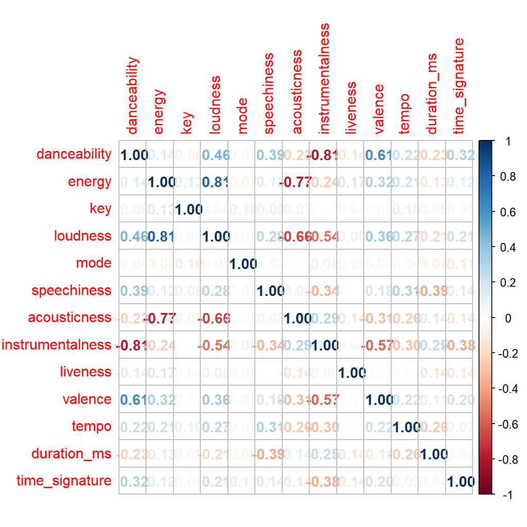

```r
c <- cor(df)
corrplot(c, method='number')
```

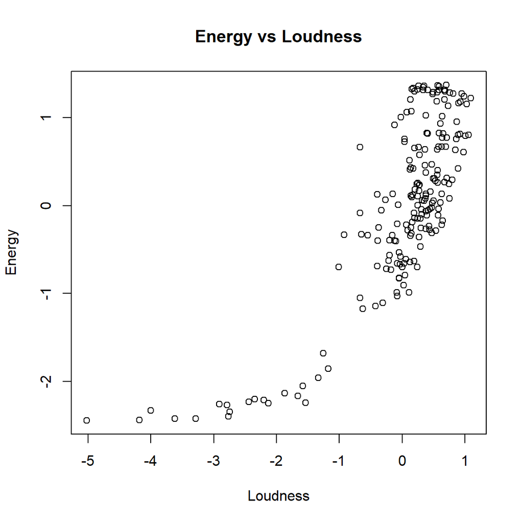

```r
plot(x=df$loudness, y=df$energy,
     xlab = 'Loudness',
     ylab = 'Energy',
     main = 'Energy vs Loudness'
     )
```

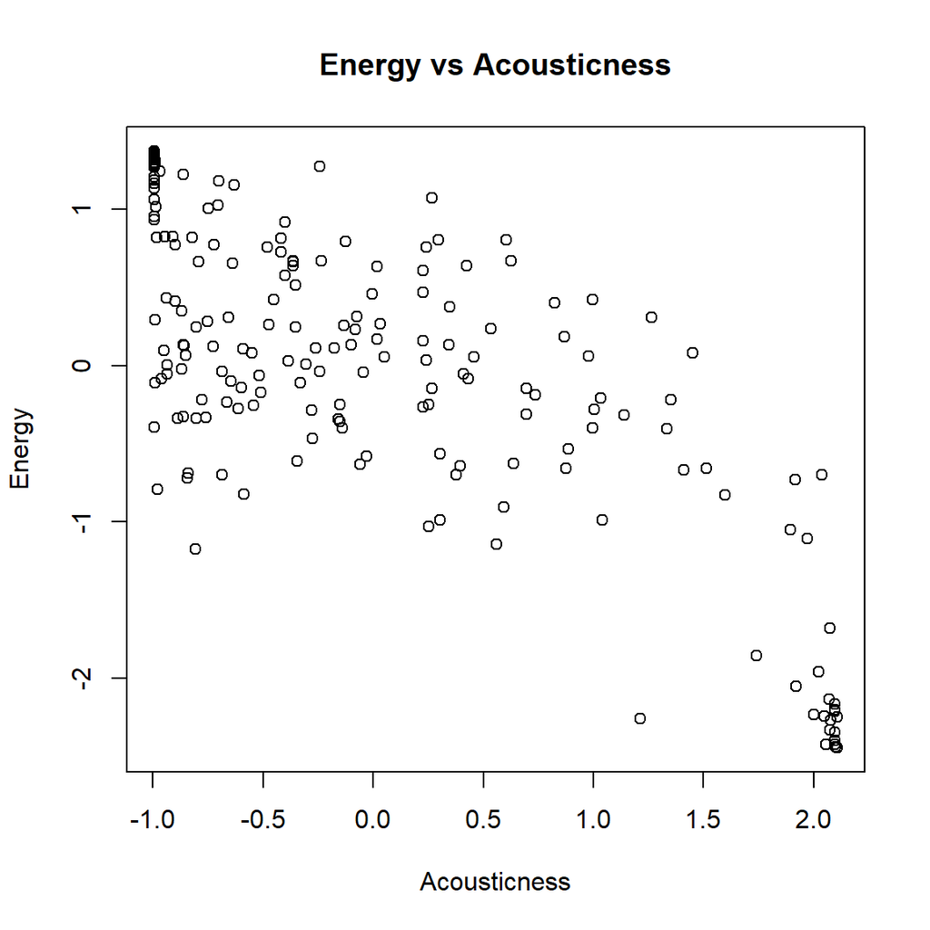

```r
plot(x=df$acousticness, y=df$energy,
     xlab = 'Acousticness',
     ylab = 'Energy',
     main = 'Energy vs Acousticness'
     )
```

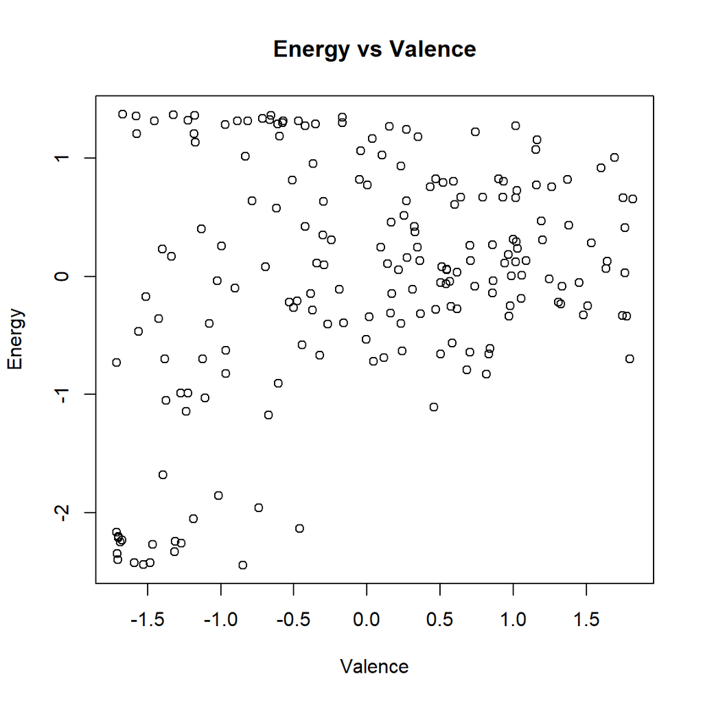

```r
plot(x=df$valence, y=df$energy,
     xlab = 'Valence',
     ylab = 'Energy',
     main = 'Energy vs Valence'
     )
```

```r
new_model <- lm(energy ~ loudness + acousticness, data = df)
summary(new_model)
```

```
##
## Call:
## lm(formula = energy ~ loudness + acousticness, data = df)
##
## Residuals:
##      Min       1Q   Median       3Q      Max
## -1.22073 -0.34349  0.00132  0.34870  1.12953
##
## Coefficients:
##                Estimate Std. Error t value Pr(>|t|)
## (Intercept)   1.001e-16  3.541e-02   0.000        1
## loudness      5.375e-01  4.753e-02  11.308  < 2e-16 ***
## acousticness -4.152e-01  4.753e-02  -8.734  1.2e-15 ***
## ---
## Signif. codes:  0 '***' 0.001 '**' 0.01 '*' 0.05 '.' 0.1 ' ' 1
##
## Residual standard error: 0.4945 on 192 degrees of freedom
## Multiple R-squared:  0.758,  Adjusted R-squared:  0.7555
## F-statistic: 300.7 on 2 and 192 DF,  p-value: < 2.2e-16
```

Postively Correlated Loudness ~ Energy: 0.8  
Valence ~ Energy: 0.3

Negatively Correlated  
Acousticness ~ Energy: -0.77

**We think Loudness and Acousticness are important to form an MLR model, because their hue(extent of their positive/ negative correlation) is high. But, these independant variables are in turn correlated (-0.6) which is not favourable. We can’t say why they are correlated (spurious) and that increases unpredictability in the energy. For a small change in loudness, energy(target variable) is significantly impacted(increases). R square values is the highest (0.758) with Loudness and Acousticness, with F statistic = 300.7 and standard error = 0.4945, whereas only Loudness has R square value = 0.6619, F statistic = 377 and standard error = 0.58. These indicate that Loudness and Acousticness together impact energy.**

## Solution-4

Conduct a partial F-test to determine if the attributes not chosen by you in *Problem-3* are significant to predict the energy.What are the null and alternate hypotheses? [ *Hint* : Use the anova function between models created in *Problem-2* and *Problem-3*]

```r
# energy is the target variable, and . means all other attributes other than energy.
without_model <- lm(energy ~ danceability + key + mode + speechiness + instrumentalness + liveness + valence + tempo +
    duration_ms + time_signature , data=df)
summary(without_model)
```

```
##
## Call:
## lm(formula = energy ~ danceability + key + mode + speechiness +
##     instrumentalness + liveness + valence + tempo + duration_ms +
##     time_signature, data = df)
##
## Residuals:
##      Min       1Q   Median       3Q      Max
## -2.42929 -0.44392  0.00664  0.55574  1.94387
##
## Coefficients:
##                    Estimate Std. Error t value Pr(>|t|)
## (Intercept)       9.442e-17  6.596e-02   0.000 1.000000
## danceability     -2.535e-01  1.253e-01  -2.023 0.044475 *
## key               1.011e-01  6.783e-02   1.490 0.137849
## mode             -2.923e-02  6.830e-02  -0.428 0.669232
## speechiness       5.135e-02  7.834e-02   0.656 0.512925
## instrumentalness -1.854e-01  1.213e-01  -1.529 0.128028
## liveness          1.526e-01  6.905e-02   2.210 0.028335 *
## valence           3.172e-01  8.636e-02   3.673 0.000314 ***
## tempo             1.047e-01  7.326e-02   1.429 0.154610
## duration_ms      -4.670e-02  7.455e-02  -0.626 0.531802
## time_signature    6.696e-02  7.250e-02   0.924 0.356942
## ---
## Signif. codes:  0 '***' 0.001 '**' 0.01 '*' 0.05 '.' 0.1 ' ' 1
##
## Residual standard error: 0.9211 on 184 degrees of freedom
## Multiple R-squared:  0.1953, Adjusted R-squared:  0.1515
## F-statistic: 4.465 on 10 and 184 DF,  p-value: 1.214e-05
```

```r
anova(new_model,without_model)
```

|  | Res.Df | RSS | Df | Sum of Sq | F | Pr(>F) |
| --- | --- | --- | --- | --- | --- | --- |
| 1 | 192 | 46.9423 | NA | NA | NA | NA |
| 2 | 184 | 156.1185 | 8 | -109.1762 | NA | NA |

```r
var.test(new_model,without_model)
```

```
##
##  F test to compare two variances
##
## data:  new_model and without_model
## F = 0.28816, num df = 192, denom df = 184, p-value < 2.2e-16
## alternative hypothesis: true ratio of variances is not equal to 1
## 95 percent confidence interval:
##  0.2162060 0.3837076
## sample estimates:
## ratio of variances
##          0.2881553
```

The null hypothesis is that the ratio of the variances of the 2 models(1 which considers the significant attributes and other that does not.) is 1.  
The alternate hypothesis is that the ratio of the variances of the 2 models is not 1, there is a difference in variance of the 2 models.

**Since p-value < 2.2e-16 which is less 0.05, null hypothesis is rejected. This is also shown in the ratio of variances which is equal to 0.2881553 (not equal to 1) hence there is significant variance between the two models.**

## Solution-5

AIC - Akaike Information Criterion is used to compare different models and determine the best fit for the data. The best-fit model according to AIC is the one that explains greatest amount of variation using the fewest number of attributes. Check [this](https://www.scribbr.com/statistics/akaike-information-criterion/) resource to learn more about AIC.

Build a model based on AIC using Stepwise AIC regression.Elucidate your observations from the new model. ( *Hint* : Use an appropriate function in [olsrr](https://www.rdocumentation.org/packages/olsrr/versions/0.5.3) package.)

```r
library(olsrr)
stepwise_model <- lm(energy ~ loudness + acousticness + danceability + valence + instrumentalness + mode + key , data = df)
summary(stepwise_model)
```

```
##
## Call:
## lm(formula = energy ~ loudness + acousticness + danceability +
##     valence + instrumentalness + mode + key, data = df)
##
## Residuals:
##      Min       1Q   Median       3Q      Max
## -1.05662 -0.24874 -0.01126  0.27930  1.25974
##
## Coefficients:
##                    Estimate Std. Error t value Pr(>|t|)
## (Intercept)       9.999e-17  2.900e-02   0.000  1.00000
## loudness          7.075e-01  4.462e-02  15.856  < 2e-16 ***
## acousticness     -3.420e-01  4.005e-02  -8.539 4.63e-15 ***
## danceability     -2.681e-01  5.308e-02  -5.051 1.04e-06 ***
## valence           2.003e-01  3.825e-02   5.238 4.35e-07 ***
## instrumentalness  1.418e-01  5.351e-02   2.650  0.00873 **
## mode             -4.863e-02  2.985e-02  -1.629  0.10491
## key               4.488e-02  2.950e-02   1.521  0.12988
## ---
## Signif. codes:  0 '***' 0.001 '**' 0.01 '*' 0.05 '.' 0.1 ' ' 1
##
## Residual standard error: 0.4049 on 187 degrees of freedom
## Multiple R-squared:  0.842,  Adjusted R-squared:  0.8361
## F-statistic: 142.3 on 7 and 187 DF,  p-value: < 2.2e-16
```

```r
print("full_model residual plots")
```

```
## [1] "full_model residual plots"
```

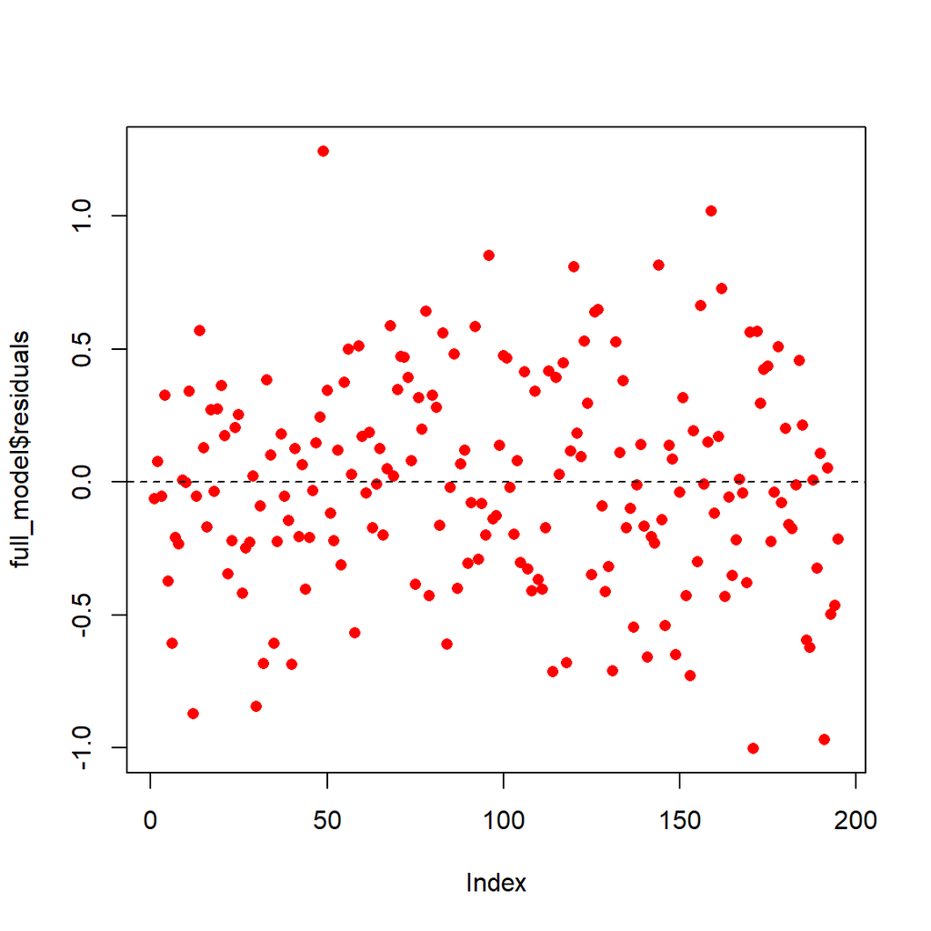

```r
plot(full_model$residuals, pch = 16, col = "red")
abline(h = 0, lty = 2)
```

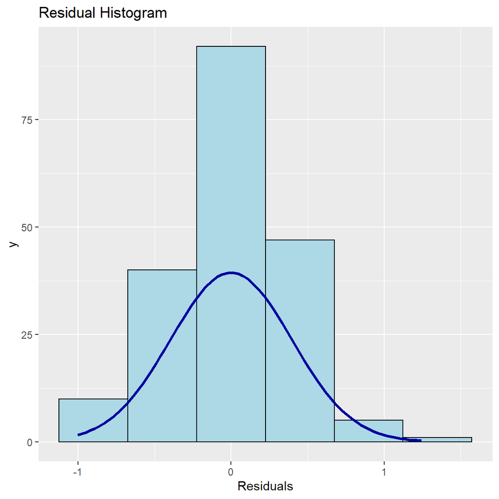

```r
ols_plot_resid_hist(full_model)
```

```r
stepwise_model <- lm(energy ~ loudness + acousticness + danceability + valence + instrumentalness + mode + key , data = df)
print("stepwise_model residual plots")
```

```
## [1] "stepwise_model residual plots"
```

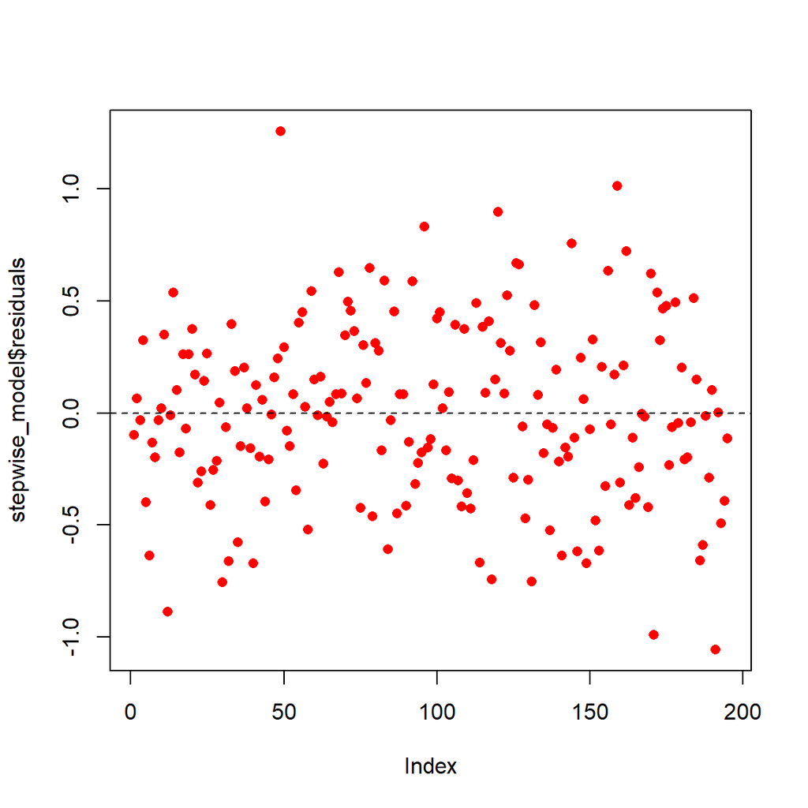

```r
plot(stepwise_model$residuals, pch = 16, col = "red")
abline(h = 0, lty = 2)
```

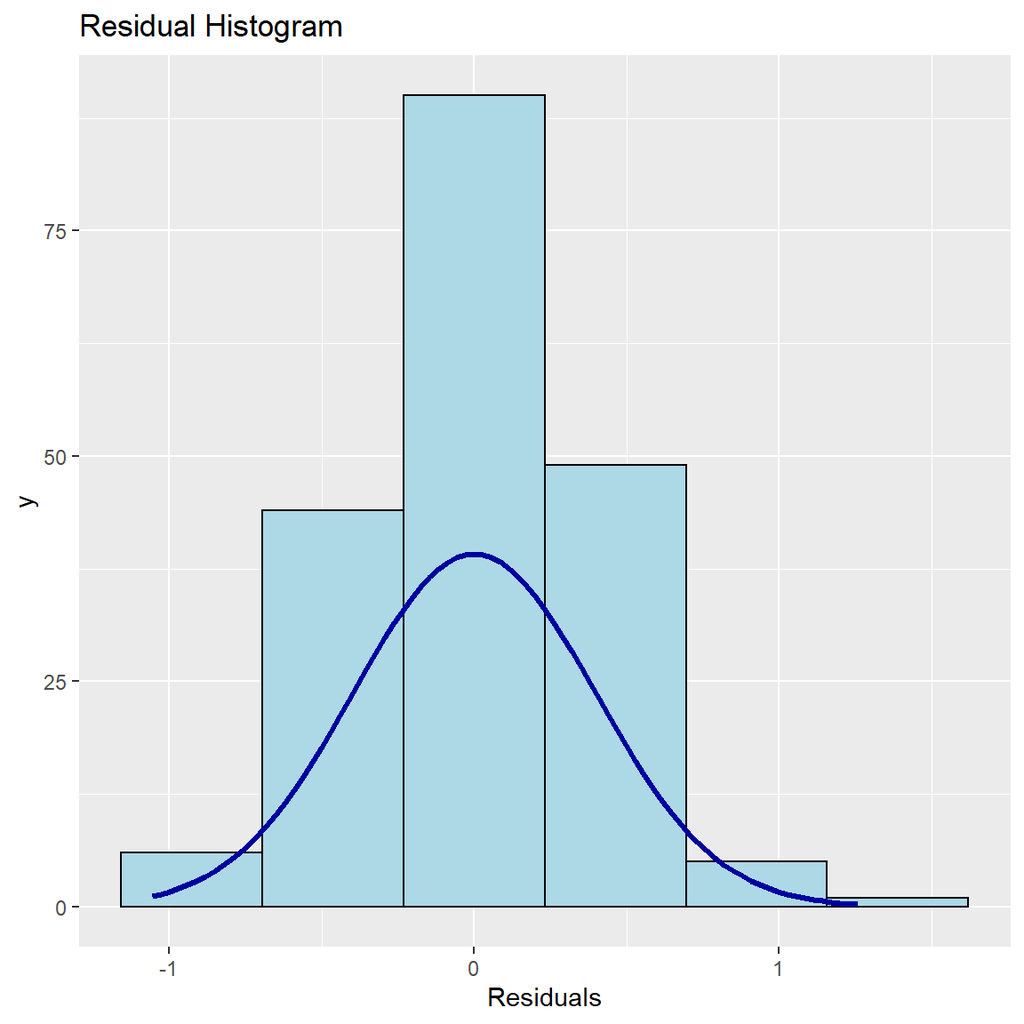

```r
ols_plot_resid_hist(stepwise_model)
```

```r
print("new_model(loudness, acousticness) residual plots")
```

```
## [1] "new_model(loudness, acousticness) residual plots"
```

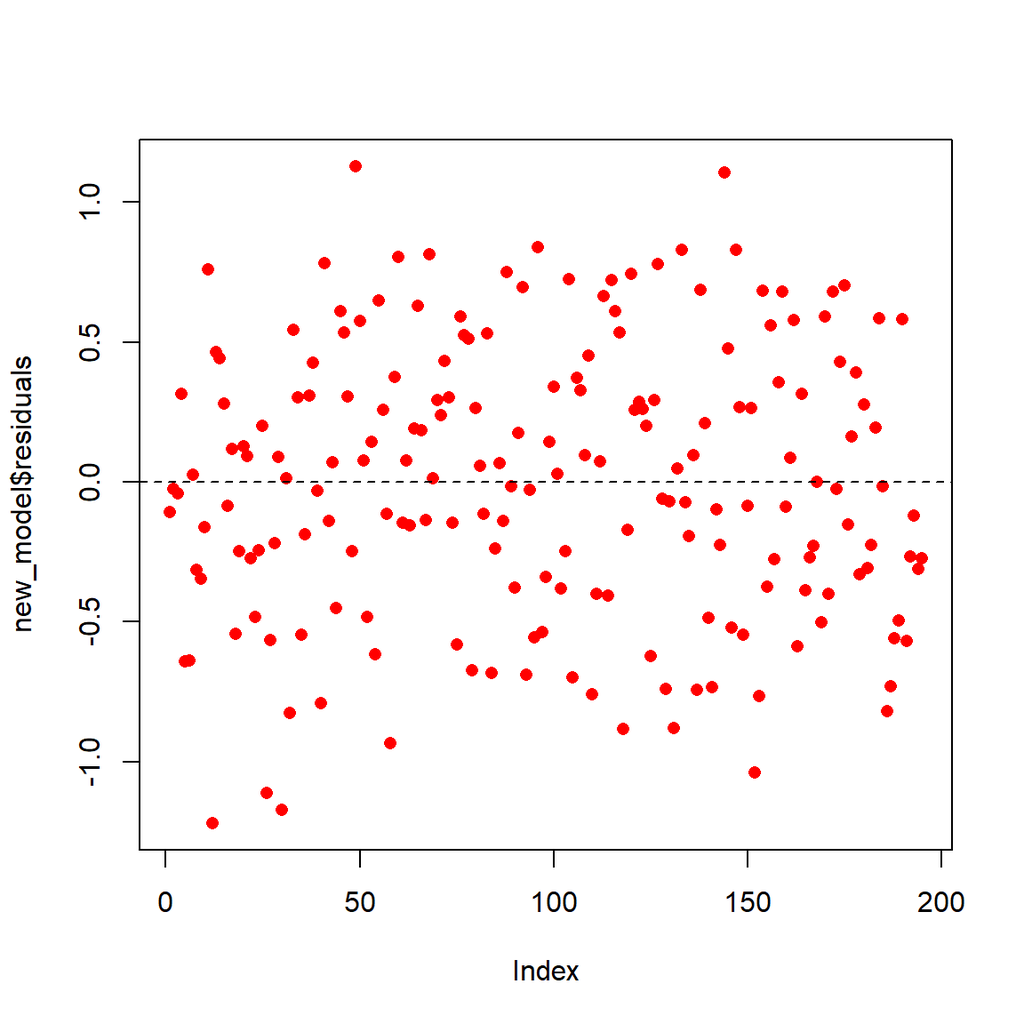

```r
plot(new_model$residuals, pch = 16, col = "red")
abline(h = 0, lty = 2)
```

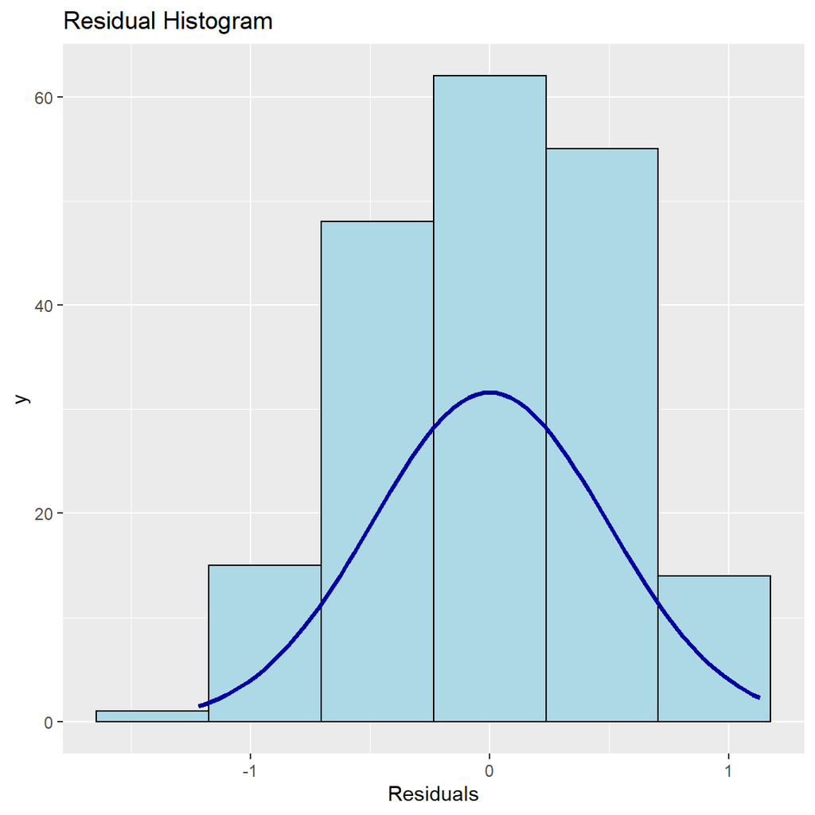

```r
ols_plot_resid_hist(new_model)
```

```r
print('loudness residual plots')
```

```
## [1] "loudness residual plots"
```

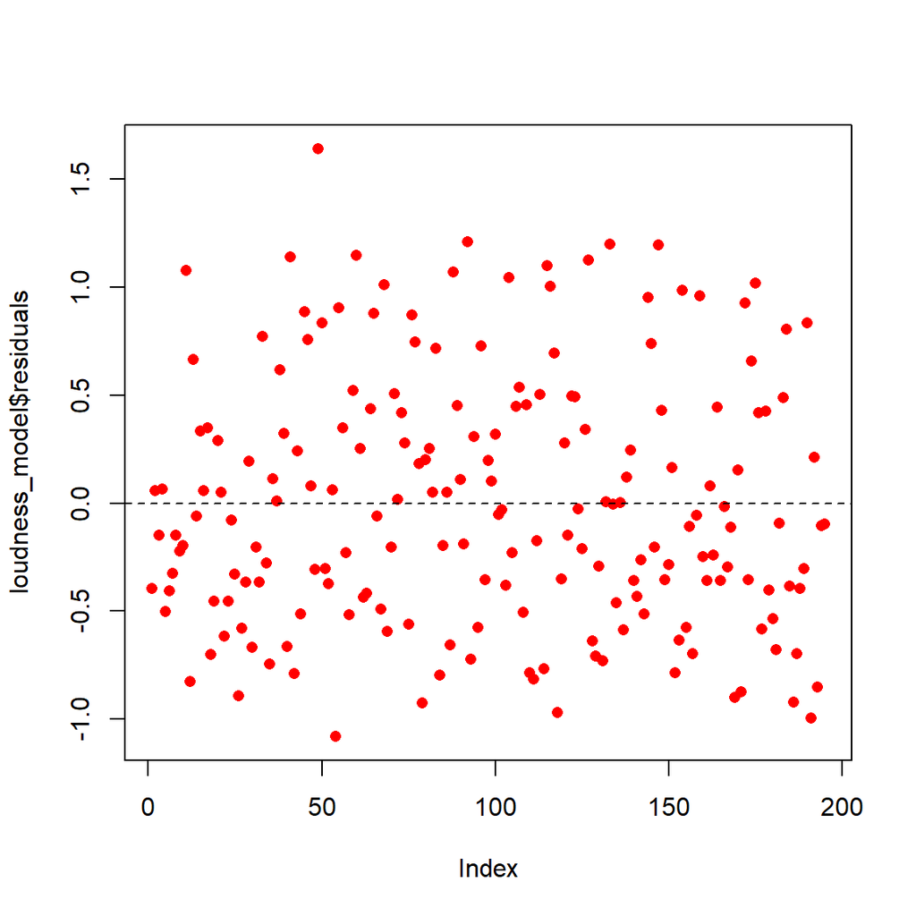

```r
loudness_model <- lm(energy ~ loudness , data = df)
plot(loudness_model$residuals, pch = 16, col = "red")
abline(h = 0, lty = 2)
```

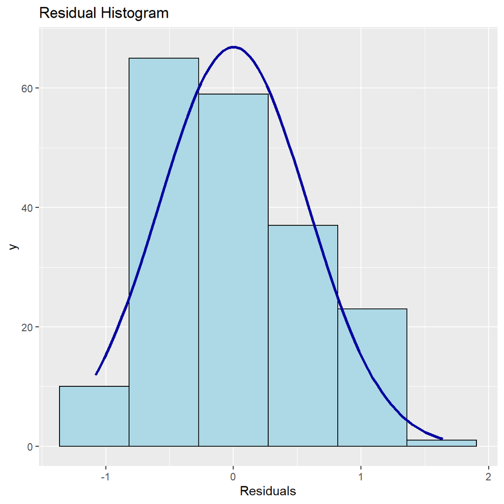

```r
ols_plot_resid_hist(loudness_model)
```

```r
library(AICcmodavg)

models <- list(full_model, stepwise_model, loudness_model, new_model)

model.names <- c('full.mod', 'stepwise.mod', 'loudness.mod', 'loudness.acousticness.mod')

aictab(cand.set = models, modnames = model.names)
```

|  | Modnames | K | AICc | Delta_AICc | ModelLik | AICcWt | LL | Cum.Wt |
| --- | --- | --- | --- | --- | --- | --- | --- | --- |
| 2 | stepwise.mod | 9 | 211.5798 | 0.000000 | 1.000000e+00 | 9.878646e-01 | -96.30342 | 0.9878646 |
| 1 | full.mod | 14 | 220.3786 | 8.798843 | 1.228444e-02 | 1.213537e-02 | -95.02266 | 1.0000000 |
| 4 | loudness.acousticness.mod | 4 | 283.9009 | 72.321061 | 1.975519e-16 | 1.951545e-16 | -137.84517 | 1.0000000 |
| 3 | loudness.mod | 3 | 347.0531 | 135.473313 | 3.822469e-30 | 3.776081e-30 | -170.46373 | 1.0000000 |

## Solution-6

Plot the residuals of the models built till now and comment on it satisfying the assumptions of MLR.

```r
print("full_model residual plots")
```

```
## [1] "full_model residual plots"
```

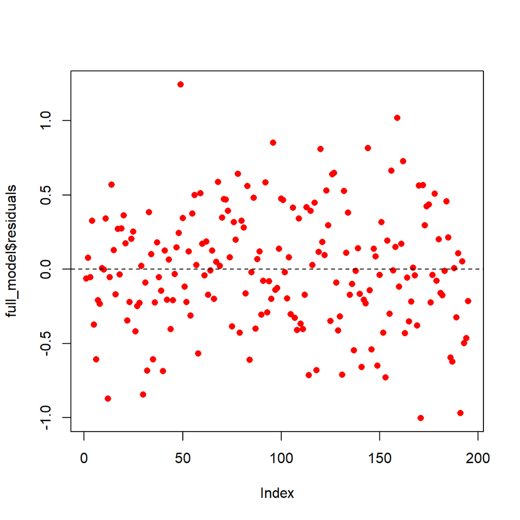

```r
plot(full_model$residuals, pch = 16, col = "red")
abline(h = 0, lty = 2)
```

```r
print("stepwise_model residual plots")
```

```
## [1] "stepwise_model residual plots"
```

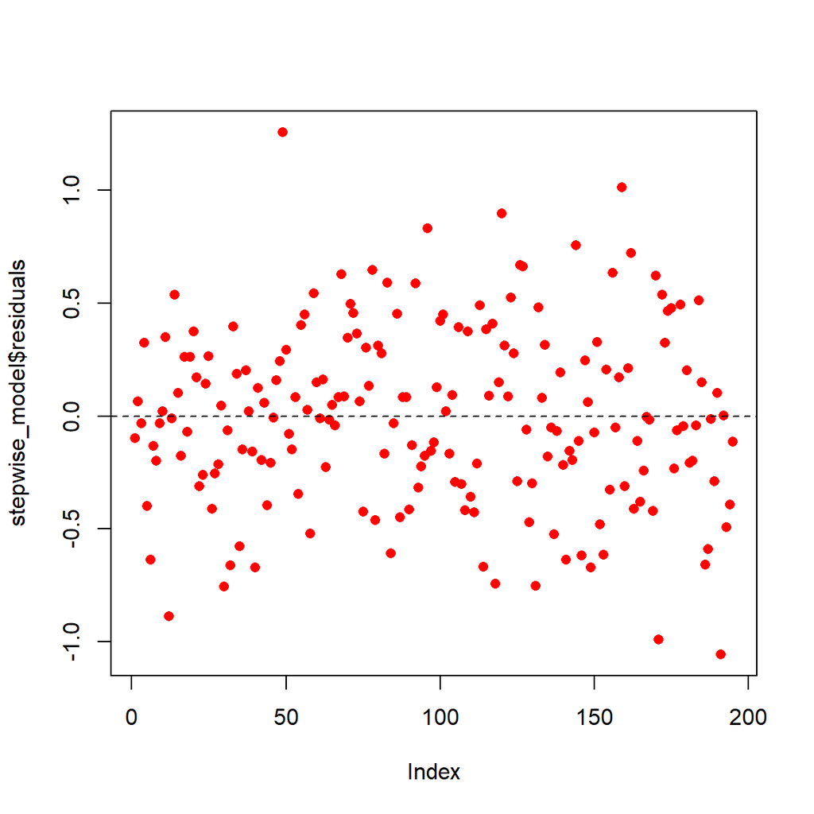

```r
plot(stepwise_model$residuals, pch = 16, col = "red")
abline(h = 0, lty = 2)
```

```r
print("new_model(loudness, acousticness) residual plots")
```

```
## [1] "new_model(loudness, acousticness) residual plots"
```

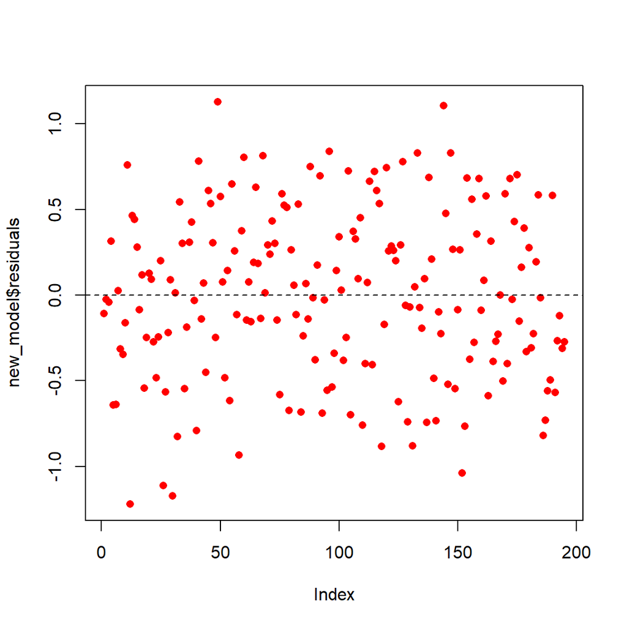

```r
plot(new_model$residuals, pch = 16, col = "red")
abline(h = 0, lty = 2)
```

```r
print('loudness residual plots')
```

```
## [1] "loudness residual plots"
```

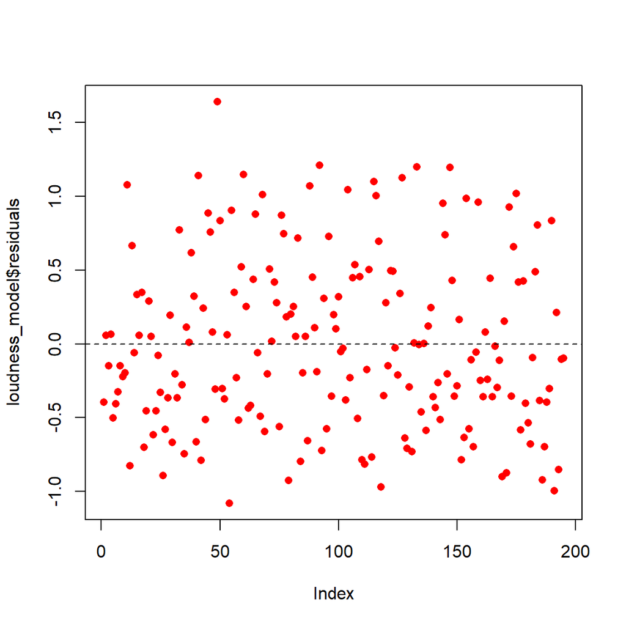

```r
plot(loudness_model$residuals, pch = 16, col = "red")
abline(h = 0, lty = 2)
```

The full model and stepwise model best satisfy the assumptions of the residuals in MLR model. The residuals are independant, and their variance is constant for all values of xi(homoscedasticity). They follow a normal distribution.  
The loudness and loudness_acousticness model don’t ideally conform to the assumptions of the residuals in MLR model. There exists multi collinearity between loudness and acousticness(0.6). Both residual plots are not exactly centered around 0. There is non-uniformity of the residuals about 0 (high absolute residual value).

## Solution-7

For the model built in *Problem-2* , determine the presence of multicollinearity using VIF. Determine if there are outliers in the data using [Cook’s Distance](https://www.statisticshowto.com/cooks-distance/). If you find any , remove the outliers and fit the model for *Problem-2* and see if the fit improves. [ *Hint* : All the relevant functions can be found in *olsrr* package. An observation can be termed as an outlier if it has a Cook’s distance of more than 4/n where n is the number of records.]

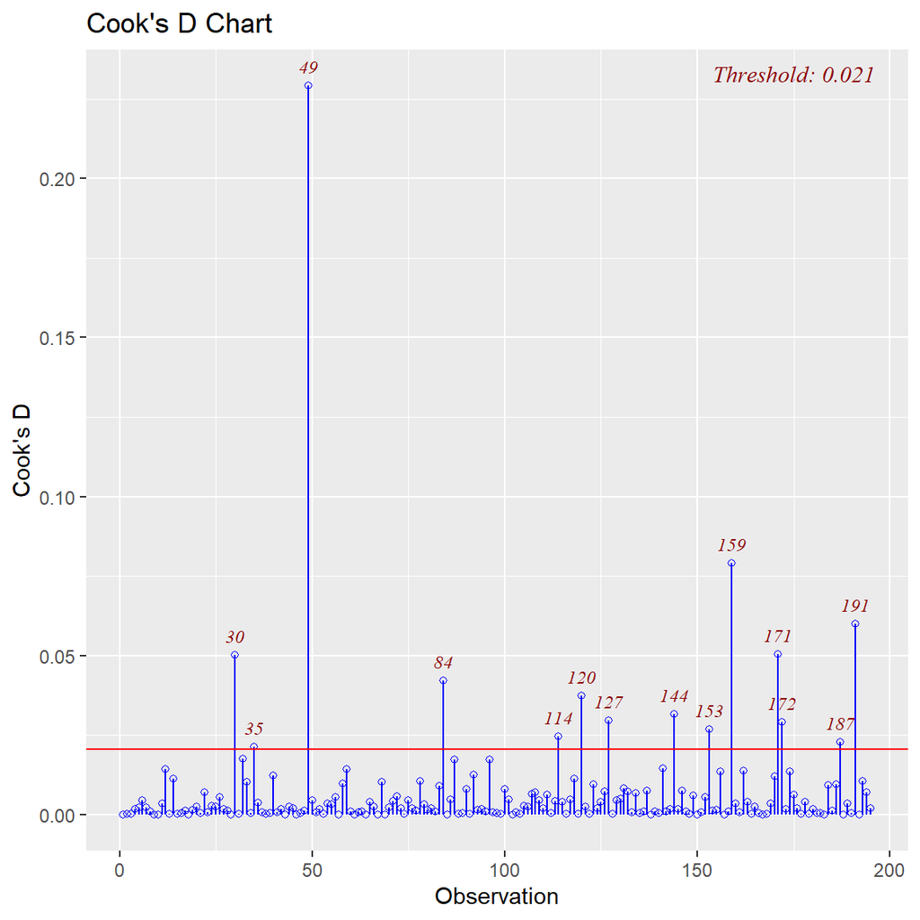

```r
cookd <- ols_plot_cooksd_chart(full_model)
```

```r
ols_vif_tol(full_model)
```

| Variables | Tolerance | VIF |
| --- | --- | --- |
| danceability | 0.2776703 | 3.601393 |
| key | 0.9467671 | 1.056226 |
| loudness | 0.4119898 | 2.427245 |
| mode | 0.9308390 | 1.074300 |
| speechiness | 0.6921660 | 1.444740 |
| acousticness | 0.5009458 | 1.996224 |
| instrumentalness | 0.2755568 | 3.629016 |
| liveness | 0.8914397 | 1.121781 |
| valence | 0.5680642 | 1.760364 |
| tempo | 0.7892957 | 1.266952 |

[output cut: 2 more lines]

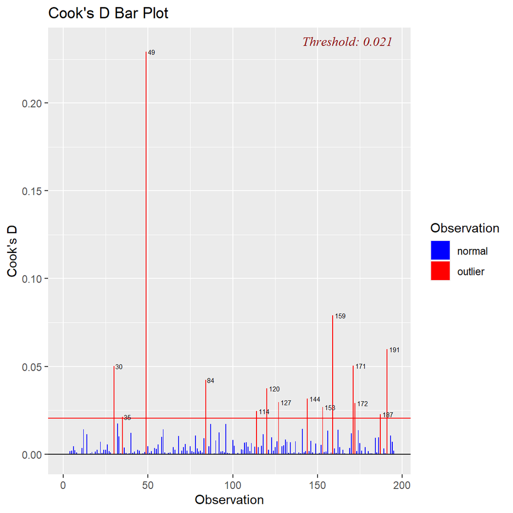

```r
k<-ols_plot_cooksd_bar(full_model, print_plot = TRUE)
```

```r
cooksD <- cooks.distance(full_model)
n <- nrow(df)
influential <- as.numeric(names(cooksD)[(cooksD > (4/n))])
new_df <- df[-influential, ]
nrow(new_df)
```

```
## [1] 181
```

```r
new_full_model <- lm(energy ~ . , data=new_df)
summary(new_full_model)
```

```
##
## Call:
## lm(formula = energy ~ ., data = new_df)
##
## Residuals:
##      Min       1Q   Median       3Q      Max
## -0.76364 -0.20836  0.01581  0.23506  0.95145
##
## Coefficients:
##                   Estimate Std. Error t value Pr(>|t|)
## (Intercept)      -0.001128   0.025283  -0.045 0.964458
## danceability     -0.258483   0.052291  -4.943 1.85e-06 ***
## key               0.088181   0.026094   3.379 0.000903 ***
## loudness          0.838411   0.045399  18.468  < 2e-16 ***
## mode             -0.012666   0.026559  -0.477 0.634036
## speechiness      -0.004528   0.032087  -0.141 0.887947
## acousticness     -0.280188   0.037293  -7.513 3.26e-12 ***
## instrumentalness  0.199483   0.051442   3.878 0.000151 ***
## liveness          0.028416   0.027232   1.043 0.298230
## valence           0.187216   0.033329   5.617 7.90e-08 ***
## tempo            -0.018193   0.029627  -0.614 0.540008
## duration_ms      -0.059788   0.028685  -2.084 0.038647 *
## time_signature    0.036680   0.028430   1.290 0.198761
## ---
## Signif. codes:  0 '***' 0.001 '**' 0.01 '*' 0.05 '.' 0.1 ' ' 1
##
## Residual standard error: 0.337 on 168 degrees of freedom
## Multiple R-squared:  0.8778, Adjusted R-squared:  0.8691
## F-statistic: 100.6 on 12 and 168 DF,  p-value: < 2.2e-16
```

The VIF score of instrumentalness and danceability is moderate (~3.60).  
VIF estimates how much the variance of a regression coefficient is inflated due to multicollinearity in the model. Generally, a VIF score between 1 and 5 is moderately correlated.This is not too high and shouldn’t be a cause for concern.

There are 14 outliers in the full model.  
Out of 195 values, 14 are removed, as shown above(the final nrow(new_df) is equal to 181). The resulting model is fitted and it’s summary statistics observed. This new model with outliers removed fits better than the original one in Solution 2. It has a higher Multiple R-squared value, lesser residual standard error and higher F-statistic; all of which lead us to conclude that this outlier-free model performs better than the with-outlier model.

Outlier free model.  
Residual standard error: 0.337  
Multiple R-squared: 0.8778  
F-statistic: 100.6

With-outlier model.  
Residual standard error: 0.4077  
Multiple R-squared: 0.844  
F-statistic: 82.08  
Thank You!